# SSVEP reward - behavioral results

Ivan Grahek & Antonio Schettino

2018-08-24

## About the code

Experiment: FSAReward (Ivan Grahek*, Antonio Schettino*, Gilles Pourtois, Ernst Koster, & Søren Andersen) (*: co-first authors) Code written by: Ivan Grahek & Antonio Schettino (2016-2018) Description: Code for the analysis of behavioral data for Experiment 1 of the SSVEP - reward project.

## Accuracy data

```r
# Clear environemnt and import data------------------------------------------------------------------------------------------------------------------------------------------------------------------------------------------------------

# clear the environment
rm(list=ls())
# clear the console
cat("\014")
```

```r
#load packages and install them if they're not installed
if (!require("pacman")) install.packages("pacman")
pacman::p_load(plyr,Rmisc,yarrr,BayesFactor,reshape2,brms, broom, tidyverse, brmstools, BEST, knitr, here, HDInterval)
# set seed
set.seed(42)
# set directory
setwd(here())
# import data
data.raw = read.csv(file = here("data","Data_behavior_exp1_48pps.csv"),header=TRUE,na.strings="NaN")

# Prepare the dataset------------------------------------------------------------------------------------------------------------------------------------------------------------------------------------------------------

### Adding and renaming variables
# rename EventType variable
names(data.raw)[names(data.raw) == "EventType"] = "MovedDots"
# add a variable with the name of the attended color instead of a numbers
data.raw$AttendedColor = ifelse(data.raw$AttendedColor==1,"red","blue")
# add a variable saying which color was linked with High_Rew (even numbers - blue was High_Rew)
data.raw$RewardedColor = ifelse(data.raw$ParticipantNo%%2==0,"blue","red")
# add a variable with the name of the moved color instead of a numbers
data.raw$MovedDots = ifelse(data.raw$MovedDots==1,"red","blue")
# split experimental phases into 6 isntead of 3 phases (trial 0-200: Bsln; trial 201-400: Acq; trial 401-600: Ext)
data.raw$ExpPhase = cut(data.raw$Trial,breaks=c(0,100,200,300,400,500,600),labels=c("Bsln1","Bsln2","Acq1","Acq2","Ext1","Ext2"))
#split experimental phases into 3 phases (trial 0-200: Bsln; trial 201-400: Acq; trial 401-600: Ext)
#data.raw$ExpPhase = cut(data.raw$Trial,breaks=c(0,200,400,600),labels=c("Bsln","Acq","Ext")) # trial 0-200: Bsln; trial 201-400: Acq; trial 401-600: Ext

### Convert variables to be used in analyses into factors
data.raw[c("ParticipantNo", "AttendedColor","RewardedColor", "MovedDots", "ExpPhase" )] =
  lapply(data.raw[c("ParticipantNo", "AttendedColor","RewardedColor", "MovedDots", "ExpPhase" )], factor)

### Create variables needed for the accuracy analyses
# count hits, false alarms, misses, correct rejections, and RT separately for each participant (their calculation is done in Matlab: see DataProcessing.m)
data.final = ddply(data.raw,.(ParticipantNo,ExpPhase,AttendedColor,RewardedColor,MovedDots),summarize,
                  numtrials=length(which(Response!=99)), # number of trials per condition (anything that is not 99 or any other number that we're not using)
                  Hits=length(which(Response==1)), # hits: attended color moved, correct response
                  FAs=length(which(Response==2)), # false alarms: attended color did not move, (wrong) response
                  Misses=length(which(Response==0)), # misses: attended color moved, no response
                  CRs=length(which(Response==3)), # correct rejections: attended color did not move, no response
                  mean.RT=mean(RT,na.rm=TRUE)) # mean RT per condition


################################################################## Calculate accuracy and RTs per condition ###############################################################################################################################################################################################################

# Prepare the data------------------------------------------------------------------------------------------------------------------------------------------------------------------------------------------------------

### Calculate Hits and False alarms
# Hits are calculated for each participant in each condition on trials when they are attending the color that moved.
# False alarms are  calculated for each participant in each condition on trials when they are attending the color that didn't move (the unattended color moved, but they responded)
# Here we create the same number of hits & fas for each of the two conditions (moved attended or not)
data.final = ddply(data.final, .(ParticipantNo,ExpPhase,AttendedColor), transform,
                 Hits = Hits[MovedDots==AttendedColor],
                 FAs = FAs[MovedDots!=AttendedColor])

# Keep only trials on which the attended color moved (we can do behavioral analysis only on those)
data.final = subset(data.final,MovedDots==AttendedColor)

### Calculate d'
# use loglinear transformation: add 0.5 to Hits, FAs, Misses, and CRs (Hautus, 1995, Behavior Research Methods, Instruments, & Computers),
# which is preferred over the 1/2N rule (Macmillan & Kaplan, 1985, Psychological Bulletin) because it results in less biased estimates of d'.
data.final =  ddply(data.final,.(ParticipantNo,ExpPhase,RewardedColor,AttendedColor,numtrials),summarize,
                      tot.Hits=Hits+.5, # hits
                      tot.FAs=FAs+.5, # false alarms
                      tot.Misses=(numtrials-tot.Hits)+.5, # misses
                      tot.CRs=(numtrials-tot.FAs)+.5, # correct rejections
                      Hit.Rate=tot.Hits/(tot.Hits+tot.Misses), # hit rate
                      FA.Rate=tot.FAs/(tot.FAs+tot.CRs), # false alarm rate
                      dprime=qnorm(Hit.Rate)-qnorm(FA.Rate),
                      Hits.RTs=mean(mean.RT,na.rm=TRUE)) # mean RTs


### Create a final dataframe for accuracy and RTs analyses
# add a new variable specifying whether the participant is attending the high or Low_Rewed color
data.final$Condition = ifelse(data.final$RewardedColor==data.final$AttendedColor,"High_Rew","Low_Rew")
# make this variable a factor for further analyses
data.final$Condition = factor(data.final$Condition)
```

### Means - raw data

```r
summary = ddply(data.final,.(ExpPhase,Condition),plyr::summarize,Mean=c(paste(round(mean(Hit.Rate, na.rm = TRUE), digits = 2), " [", round(hdi(Hit.Rate)[[1]], digits = 2), " ", round(hdi(Hit.Rate)[[2]], digits = 2), "]")))

names(summary) = c("Reward phase", "Reward probability", "Hit Rate")

summary$`Reward phase` = recode(summary$`Reward phase`,
                                "Acq1" = "Acquisition1",
                                "Acq2" = "Acquisition2",
                                "Bsln1" = "Baseline1",
                                "Bsln2" = "Baseline2",
                                "Ext1" = "Extinction1",
                                "Ext2" = "Extinction2")

summary$`Reward probability` = recode(summary$`Reward probability`,
                           "High_Rew" = "High",
                           "Low_Rew" = "Low")

summary = as.data.frame(summary)

kable(summary, caption = "Hit rates per condition")
```

Hit rates per condition

| Reward phase | Reward probability | Hit Rate |
| --- | --- | --- |
| Baseline1 | High | 0.59 [ 0.28 0.76 ] |
| Baseline1 | Low | 0.57 [ 0.25 0.85 ] |
| Baseline2 | High | 0.62 [ 0.37 0.81 ] |
| Baseline2 | Low | 0.61 [ 0.41 0.78 ] |
| Acquisition1 | High | 0.61 [ 0.33 0.8 ] |
| Acquisition1 | Low | 0.64 [ 0.47 0.86 ] |
| Acquisition2 | High | 0.64 [ 0.31 0.76 ] |
| Acquisition2 | Low | 0.63 [ 0.45 0.79 ] |
| Extinction1 | High | 0.62 [ 0.33 0.77 ] |
| Extinction1 | Low | 0.61 [ 0.43 0.85 ] |
| Extinction2 | High | 0.62 [ 0.28 0.78 ] |
| Extinction2 | Low | 0.62 [ 0.35 0.78 ] |

### Plot

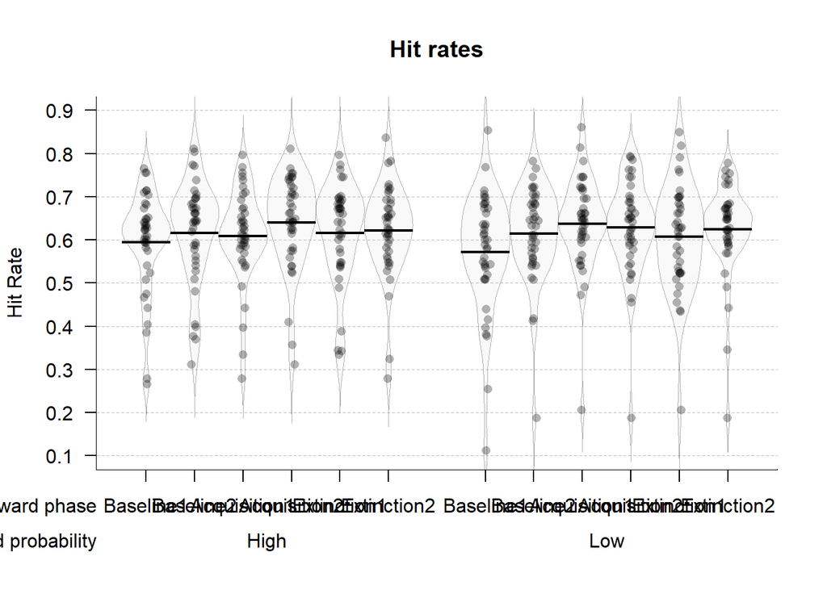

```r
# # Plot Hit rates------------------------------------------------------------------------------------------------------------------------------------------------------------------------------------------------------
# Prepare the dataset
data.plot = data.final

# rename variables
colnames(data.plot)[colnames(data.plot)=="ExpPhase"] <- "Reward phase"
colnames(data.plot)[colnames(data.plot)=="Condition"] <- "Reward probability"

# rename conditions
data.plot$`Reward phase` = recode(data.plot$`Reward phase`,
                                "Acq1" = "Acquisition1",
                                "Acq2" = "Acquisition2",
                                "Bsln1" = "Baseline1",
                                "Bsln2" = "Baseline2",
                                "Ext1" = "Extinction1",
                                "Ext2" = "Extinction2")


data.plot$`Reward probability` = recode(data.plot$`Reward probability`,
                                      "High_Rew" = "High",
                                      "Low_Rew" = "Low")
  # Pirate plot
  pirateplot(formula=Hit.Rate ~ `Reward phase` + `Reward probability`, # dependent~independent variables
             data=data.plot, # data frame
             main="Hit rates", # main title
             ylim=c(0.1,0.9), # y-axis: limits
             ylab="Hit Rate", # y-axis: label
             theme=0, # preset theme (0: use your own)
             point.col="black", # points: color
             point.o=.3, # points: opacity (0-1)
             avg.line.col="black", # average line: color
             avg.line.lwd=2, # average line: line width
             avg.line.o=1, # average line: opacity (0-1)
             bean.b.col="black", # bean border, color
             bean.lwd=0.6, # bean border, line width
             bean.lty=1, # bean border, line type (1: solid; 2:dashed; 3: dotted; ...)
             bean.b.o=0.3, # bean border, opacity (0-1)
             bean.f.col="gray", # bean filling, color
             bean.f.o=.1, # bean filling, opacity (0-1)
             cap.beans=FALSE, # max and min values of bean densities are capped at the limits found in the data
             gl.col="gray", # gridlines: color
             gl.lty=2, # gridlines: line type (1: solid; 2:dashed; 3: dotted; ...)
             cex.lab=1, # axis labels: size
             cex.axis=1, # axis numbers: size
             cex.names = 1,
             bty="l", # plot box type
             back.col="white") # background, color
```

### Statistics

```r
# Set the working directory in order to load the models
# Set working directory
setwd(here("brms_models"))

# # referencing for easier interpretation
# data.final$ExpPhase=relevel(data.final$ExpPhase,ref="Bsln1")
# data.final$Condition=relevel(data.final$Condition,ref="High_Rew")
#
#
# #Interaction model
# model.full.Acc = brm(Hit.Rate ~ ExpPhase * Condition + (ExpPhase * Condition|ParticipantNo),
#                  data=data.final,
#                  family=gaussian(),
#                  warmup = 2000,
#                  iter = 10000,
#                  save_all_pars = TRUE,
#                  control = list(adapt_delta = 0.99),
#                  cores = 4,
#                  sample_prior = TRUE)
# saveRDS(model.full.Acc,file="model.full.Acc.6phases.rds")

#read in the models and comparisons
model.full.Acc = readRDS("model.full.Acc.6phases.rds")
```

### Checking the best model

Plotting the chains

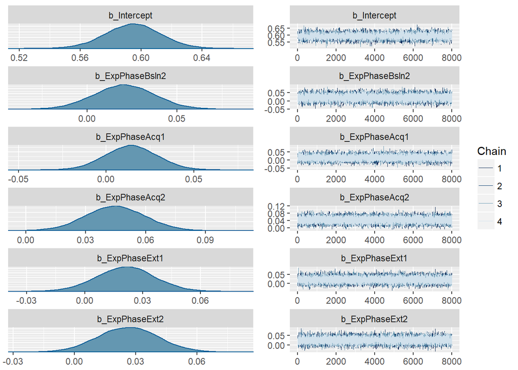

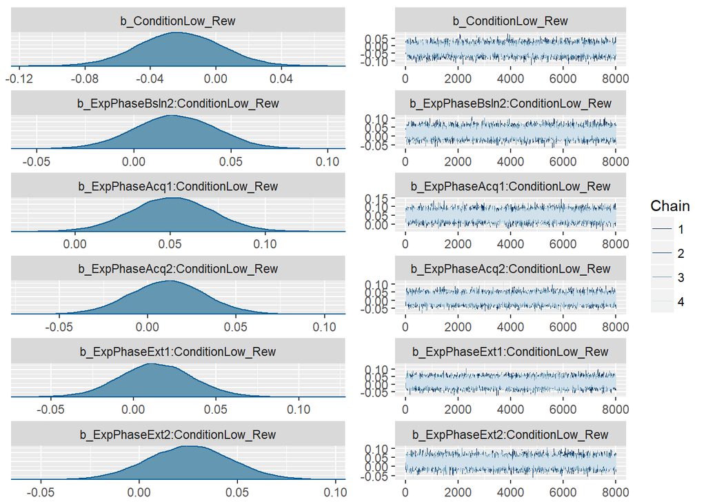

```r
# Plot chains
plot(model.full.Acc, pars = "^b_", ask = FALSE, N=6)
```

Summary of the best model

```r
# Summary of the best model
print(tidy(model.full.Acc, par_type = "non-varying"), digits = 1)
```

```
##                              term estimate std.error  lower upper
## 1                       Intercept     0.59      0.02  0.564  0.62
## 2                   ExpPhaseBsln2     0.02      0.02 -0.007  0.05
## 3                    ExpPhaseAcq1     0.01      0.01 -0.010  0.04
## 4                    ExpPhaseAcq2     0.04      0.01  0.021  0.07
## 5                    ExpPhaseExt1     0.02      0.01 -0.004  0.05
## 6                    ExpPhaseExt2     0.03      0.01  0.002  0.05
## 7                ConditionLow_Rew    -0.02      0.03 -0.064  0.02
## 8  ExpPhaseBsln2:ConditionLow_Rew     0.02      0.02 -0.014  0.06
## 9   ExpPhaseAcq1:ConditionLow_Rew     0.05      0.02  0.016  0.09
## 10  ExpPhaseAcq2:ConditionLow_Rew     0.01      0.02 -0.024  0.05
## 11  ExpPhaseExt1:ConditionLow_Rew     0.01      0.02 -0.022  0.05
## 12  ExpPhaseExt2:ConditionLow_Rew     0.03      0.02 -0.010  0.06
```

### Plotting the best model

#### Sample from the posterior

```r
# Analyzing the posterior and differences between conditions

post = posterior_samples(model.full.Acc, "^b")


################################################ Baseline 1 ####

######### High reward
Baseline1_High = post[["b_Intercept"]]
######### Low reward
Baseline1_Low = post[["b_Intercept"]] +
  post[["b_ConditionLow_Rew"]]

################################################ Baseline 2 ####

######### High reward
Baseline2_High = post[["b_Intercept"]] +
  post[["b_ExpPhaseBsln2"]]
######### Low reward
Baseline2_Low = post[["b_Intercept"]] +
  post[["b_ExpPhaseBsln2"]] +
  post[["b_ConditionLow_Rew"]] +
  post[["b_ExpPhaseBsln2:ConditionLow_Rew"]]

################################################ Acquistion 1

######### High reward
Acquisition1_High = post[["b_Intercept"]] +
  post[["b_ExpPhaseAcq1"]]
######### Low reward
Acquisition1_Low = post[["b_Intercept"]] +
  post[["b_ExpPhaseAcq1"]] +
  post[["b_ConditionLow_Rew"]] +
  post[["b_ExpPhaseAcq1:ConditionLow_Rew"]]

################################################ Acquistion 2

######### High reward
Acquisition2_High = post[["b_Intercept"]] +
  post[["b_ExpPhaseAcq2"]]
######### Low reward
Acquisition2_Low = post[["b_Intercept"]] +
  post[["b_ExpPhaseAcq2"]] +
  post[["b_ConditionLow_Rew"]] +
  post[["b_ExpPhaseAcq2:ConditionLow_Rew"]]

################################################ Extinction 1

######### High reward
Extinction1_High = post[["b_Intercept"]] +
  post[["b_ExpPhaseExt1"]]
######### Low reward
Extinction1_Low = post[["b_Intercept"]] +
  post[["b_ExpPhaseExt1"]] +
  post[["b_ConditionLow_Rew"]] +
  post[["b_ExpPhaseExt1:ConditionLow_Rew"]]

################################################ Extinction 2

######### High reward
Extinction2_High = post[["b_Intercept"]] +
  post[["b_ExpPhaseExt2"]]
######### Low reward
Extinction2_Low = post[["b_Intercept"]] +
  post[["b_ExpPhaseExt2"]] +
  post[["b_ConditionLow_Rew"]] +
  post[["b_ExpPhaseExt2:ConditionLow_Rew"]]
```

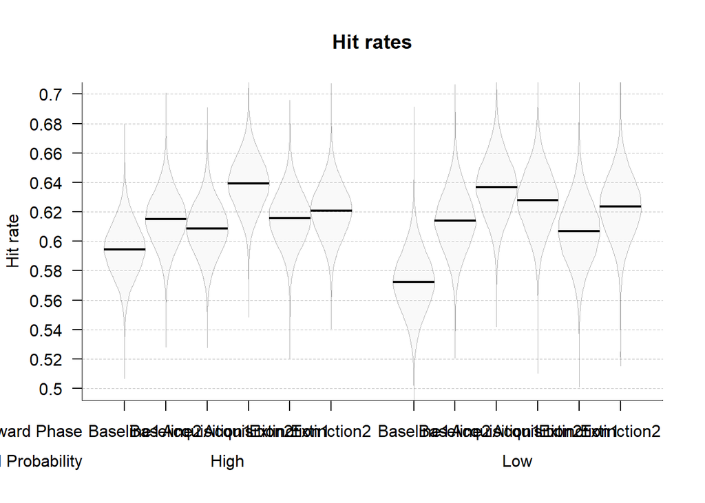

```r
# make a data frame
posterior_conditions = melt(data.frame(Baseline1_High, Baseline2_High, Baseline1_Low, Baseline2_Low, Acquisition1_High, Acquisition1_Low, Acquisition2_High, Acquisition2_Low, Extinction1_High, Extinction1_Low, Extinction2_High, Extinction2_Low))

posterior_conditions =  posterior_conditions %>% separate(variable, c("Reward Phase", "Reward Probability"), "_", extra = "merge")

names(posterior_conditions)[3] = "Hit rate"

# Pirate plot
pirateplot(formula = `Hit rate` ~ `Reward Phase` + `Reward Probability`, # dependent~independent variables
             data=posterior_conditions, # data frame
             main="Hit rates", # main title
             ylim=c(0.5, 0.7), # y-axis: limits
             ylab="Hit rate", # y-axis: label
             theme=0, # preset theme (0: use your own)
             avg.line.col="black", # average line: color
             avg.line.lwd=2, # average line: line width
             avg.line.o=1, # average line: opacity (0-1)
             bean.b.col="black", # bean border, color
             bean.lwd=0.6, # bean border, line width
             bean.lty=1, # bean border, line type (1: solid; 2:dashed; 3: dotted; ...)
             bean.b.o=0.3, # bean border, opacity (0-1)
             bean.f.col="gray", # bean filling, color
             bean.f.o=.1, # bean filling, opacity (0-1)
             cap.beans=FALSE, # max and min values of bean densities are capped at the limits found in the data
             gl.col="gray", # gridlines: color
             gl.lty=2, # gridlines: line type (1: solid; 2:dashed; 3: dotted; ...)
             cex.lab=1, # axis labels: size
             cex.axis=1, # axis numbers: size
             cex.names = 1,
             sortx = "sequential",
             bty="l", # plot box type
             back.col="white") # background, color
```

Table of means across conditions

```r
# Make a table with conditions
posterior_means = as.data.frame(c("Baseline1 High Reward",
                                  "Baseline2 High Reward",
                                  "Baseline1 Low Reward",
                                  "Baseline2 Low Reward",
                                  "Acquisition1 High Reward",
                                  "Acquisition2 High Reward",
                                  "Acquisition1 Low Reward",
                                  "Acquisition2 Low Reward",
                                  "Extinction1 High Reward",
                                  "Extinction2 High Reward",
                                  "Extinction1 Low Reward",
                                  "Extinction2 Low Reward"))

names(posterior_means)[1] = "Condition"

posterior_means$Mean = c(paste(round(mean(Baseline1_High), digits = 2), " [", round(hdi(Baseline1_High)[[1]], digits = 2), " ", round(hdi(Baseline1_High)[[2]], digits = 2), "]"),
                         paste(round(mean(Baseline2_High), digits = 2), " [", round(hdi(Baseline2_High)[[1]], digits = 2), " ", round(hdi(Baseline2_High)[[2]], digits = 2), "]"),
                        paste(round(mean(Baseline1_Low), digits = 2), " [", round(hdi(Baseline1_Low)[[1]], digits = 2), " ", round(hdi(Baseline1_Low)[[2]], digits = 2), "]"),
                        paste(round(mean(Baseline2_Low), digits = 2), " [", round(hdi(Baseline2_Low)[[1]], digits = 2), " ", round(hdi(Baseline2_Low)[[2]], digits = 2), "]"),
                        paste(round(mean(Acquisition1_High), digits = 2), " [", round(hdi(Acquisition1_High)[[1]], digits = 2), " ", round(hdi(Acquisition1_High)[[2]], digits = 2), "]"),
                        paste(round(mean(Acquisition2_High), digits = 2), " [", round(hdi(Acquisition2_High)[[1]], digits = 2), " ", round(hdi(Acquisition2_High)[[2]], digits = 2), "]"),
                        paste(round(mean(Acquisition1_Low), digits = 2), " [", round(hdi(Acquisition1_Low)[[1]], digits = 2), " ", round(hdi(Acquisition1_Low)[[2]], digits = 2), "]"),
                         paste(round(mean(Acquisition2_Low), digits = 2), " [", round(hdi(Acquisition2_Low)[[1]], digits = 2), " ", round(hdi(Acquisition2_Low)[[2]], digits = 2), "]"),
                        paste(round(mean(Extinction1_High), digits = 2), " [", round(hdi(Extinction1_High)[[1]], digits = 2), " ", round(hdi(Extinction1_High)[[2]], digits = 2), "]"),
                         paste(round(mean(Extinction2_High), digits = 2), " [", round(hdi(Extinction2_High)[[1]], digits = 2), " ", round(hdi(Extinction2_High)[[2]], digits = 2), "]"),
                        paste(round(mean(Extinction1_Low), digits = 2), " [", round(hdi(Extinction1_Low)[[1]], digits = 2), " ", round(hdi(Extinction1_Low)[[2]], digits = 2), "]"),
                        paste(round(mean(Extinction2_Low), digits = 2), " [", round(hdi(Extinction2_Low)[[1]], digits = 2), " ", round(hdi(Extinction2_Low)[[2]], digits = 2), "]"))

names(posterior_means)[2] = "Mean [HDI]"

posterior_means =  posterior_means %>% separate(Condition, c("Reward Phase", "Reward Probability"), " ", extra = "merge")

kable(posterior_means, caption = "Means per condition")
```

Means per condition

| Reward Phase | Reward Probability | Mean [HDI] |
| --- | --- | --- |
| Baseline1 | High Reward | 0.59 [ 0.56 0.63 ] |
| Baseline2 | High Reward | 0.62 [ 0.58 0.65 ] |
| Baseline1 | Low Reward | 0.57 [ 0.53 0.61 ] |
| Baseline2 | Low Reward | 0.61 [ 0.57 0.65 ] |
| Acquisition1 | High Reward | 0.61 [ 0.57 0.64 ] |
| Acquisition2 | High Reward | 0.64 [ 0.6 0.67 ] |
| Acquisition1 | Low Reward | 0.64 [ 0.6 0.68 ] |
| Acquisition2 | Low Reward | 0.63 [ 0.59 0.67 ] |
| Extinction1 | High Reward | 0.62 [ 0.58 0.65 ] |
| Extinction2 | High Reward | 0.62 [ 0.58 0.66 ] |
| Extinction1 | Low Reward | 0.61 [ 0.56 0.65 ] |
| Extinction2 | Low Reward | 0.62 [ 0.58 0.67 ] |

### Inference about the best model

Check the difference between baseline1 vs. baseline2 in high reward

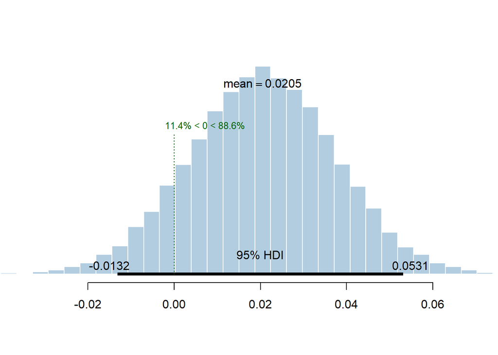

```r
Diff_Bsln1_Bsln2_High = Baseline2_High - Baseline1_High
plotPost(Diff_Bsln1_Bsln2_High, xlab = "", col = "#b3cde0", showCurve = FALSE, cex = 1, compVal = 0)
```

Check the difference between baseline1 vs. baseline2 in low reward

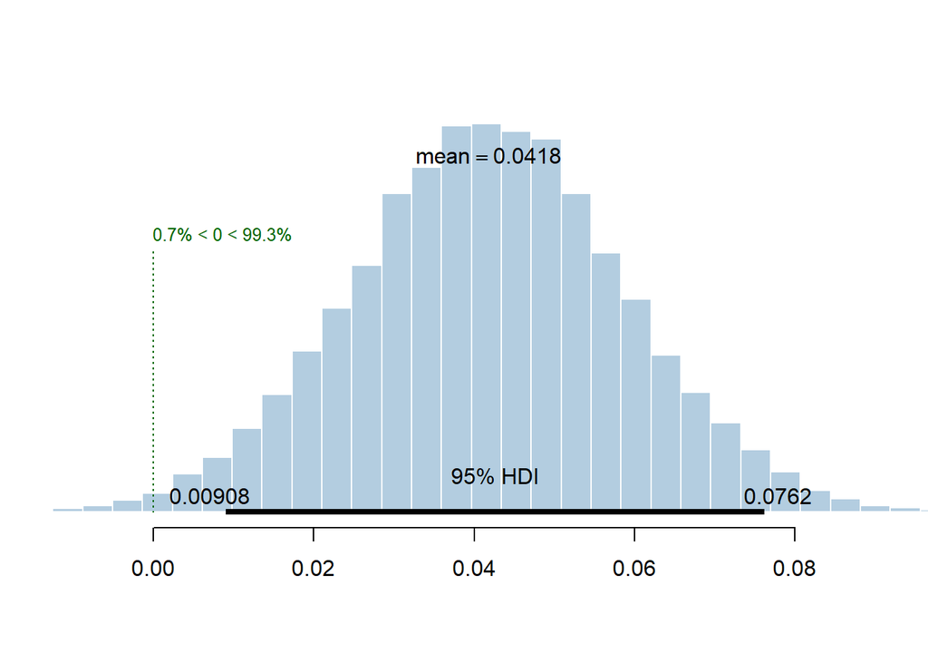

```r
Diff_Bsln1_Bsln2_Low = Baseline2_Low - Baseline1_Low
plotPost(Diff_Bsln1_Bsln2_Low, xlab = "", col = "#b3cde0", showCurve = FALSE, cex = 1, compVal = 0)
```

Check the difference between baseline2 vs. acquisition1 in high reward

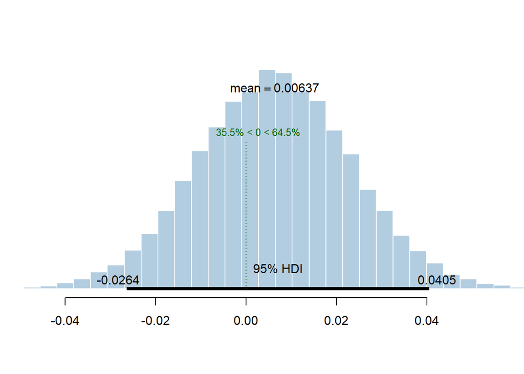

```r
Diff_Bsln2_Acq1_High = Baseline2_High - Acquisition1_High
plotPost(Diff_Bsln2_Acq1_High, xlab = "", col = "#b3cde0", showCurve = FALSE, cex = 1, compVal = 0)
```

Check the difference between baseline2 vs. acquisition1 in low reward

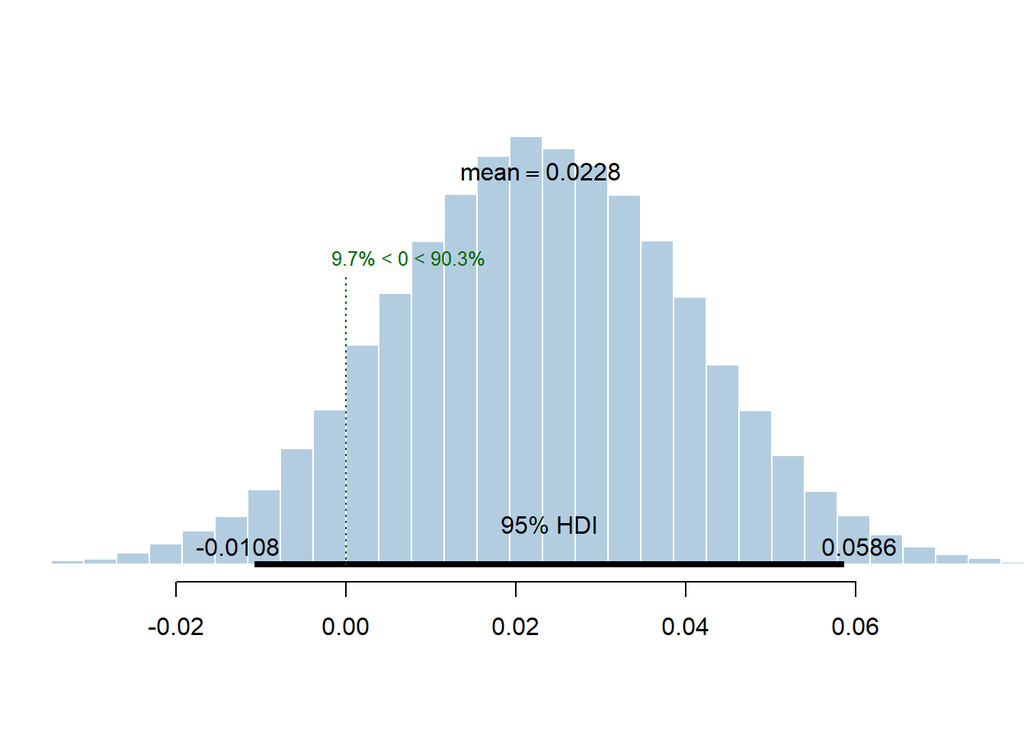

```r
Diff_Bsln2_Acq1_Low = Acquisition1_Low - Baseline2_Low
plotPost(Diff_Bsln2_Acq1_Low, xlab = "", col = "#b3cde0", showCurve = FALSE, cex = 1, compVal = 0)
```

## Reaction times

### Means - raw data

```r
summary = ddply(data.final,.(ExpPhase,Condition),plyr::summarize,Mean=c(paste(round(mean(Hits.RTs, na.rm = TRUE), digits = 2), " [", round(hdi(Hits.RTs)[[1]], digits = 2), " ", round(hdi(Hits.RTs)[[2]], digits = 2), "]")))

names(summary) = c("Reward phase", "Reward probability", "Reaction times")

summary$`Reward phase` = recode(summary$`Reward phase`,
                                "Acq1" = "Acquisition1",
                                "Acq2" = "Acquisition2",
                                "Bsln1" = "Baseline1",
                                "Bsln2" = "Baseline2",
                                "Ext1" = "Extinction1",
                                "Ext2" = "Extinction2")

summary$`Reward probability` = recode(summary$`Reward probability`,
                           "High_Rew" = "High",
                           "Low_Rew" = "Low")

summary = as.data.frame(summary)

kable(summary, caption = "Reaction times per condition")
```

Reaction times per condition

| Reward phase | Reward probability | Reaction times |
| --- | --- | --- |
| Baseline1 | High | 548.8 [ 471 613.76 ] |
| Baseline1 | Low | 551.68 [ 458.26 629.69 ] |
| Baseline2 | High | 546.07 [ 443.45 620.36 ] |
| Baseline2 | Low | 554.75 [ 479.48 650.73 ] |
| Acquisition1 | High | 522.8 [ 437.9 604.61 ] |
| Acquisition1 | Low | 541.89 [ 457.58 593.47 ] |
| Acquisition2 | High | 529.67 [ 462 598.58 ] |
| Acquisition2 | Low | 536.08 [ 471 618.25 ] |
| Extinction1 | High | 529.58 [ 457.88 596.17 ] |
| Extinction1 | Low | 535.2 [ 444.89 629.69 ] |
| Extinction2 | High | 526.88 [ 456 639.89 ] |
| Extinction2 | Low | 541.75 [ 450.11 633.28 ] |

### Plot

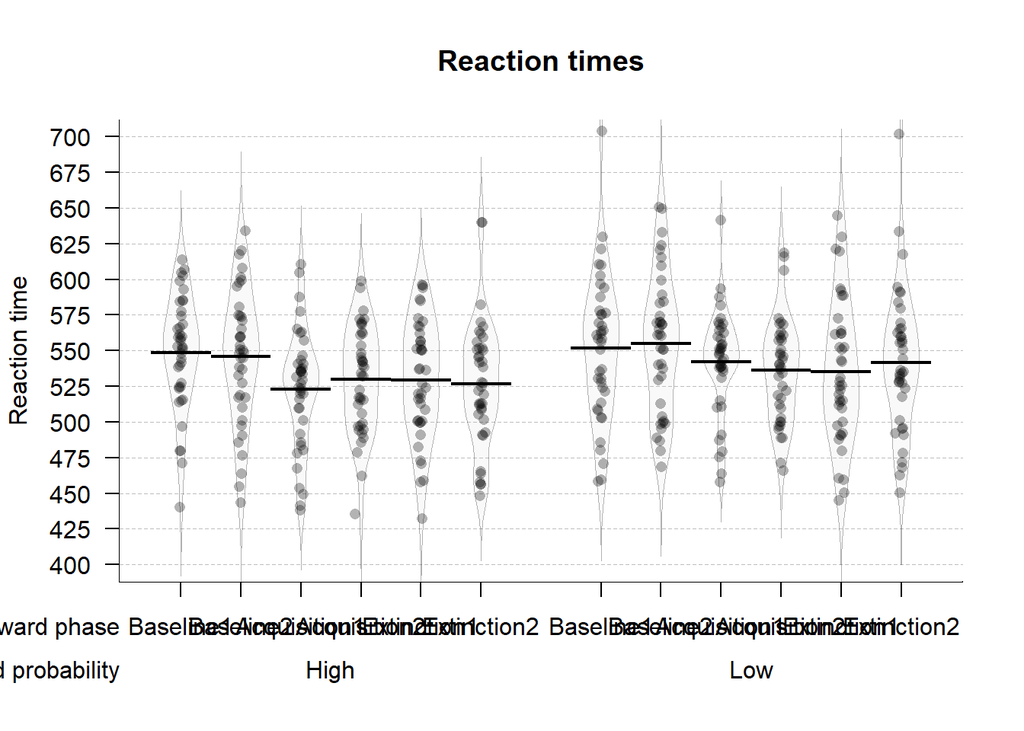

```r
# Prepare the dataset
data.plot = data.final

# rename variables
colnames(data.plot)[colnames(data.plot)=="ExpPhase"] = "Reward phase"
colnames(data.plot)[colnames(data.plot)=="Condition"] = "Reward probability"

# rename conditions
data.plot$`Reward phase` = recode(data.plot$`Reward phase`,
                                "Acq1" = "Acquisition1",
                                "Acq2" = "Acquisition2",
                                "Bsln1" = "Baseline1",
                                "Bsln2" = "Baseline2",
                                "Ext1" = "Extinction1",
                                "Ext2" = "Extinction2")

data.plot$`Reward probability` = recode(data.plot$`Reward probability`,
                                      "High_Rew" = "High",
                                      "Low_Rew" = "Low")

# Pirate plot
  pirateplot(formula = Hits.RTs ~ `Reward phase` + `Reward probability`, # dependent~independent variables
             data=data.plot, # data frame
             main="Reaction times", # main title
             ylim=c(400,700), # y-axis: limits
             ylab="Reaction time", # y-axis: label
             theme=0, # preset theme (0: use your own)
             point.col="black", # points: color
             point.o=.3, # points: opacity (0-1)
             avg.line.col="black", # average line: color
             avg.line.lwd=2, # average line: line width
             avg.line.o=1, # average line: opacity (0-1)
             bean.b.col="black", # bean border, color
             bean.lwd=0.6, # bean border, line width
             bean.lty=1, # bean border, line type (1: solid; 2:dashed; 3: dotted; ...)
             bean.b.o=0.3, # bean border, opacity (0-1)
             bean.f.col="gray", # bean filling, color
             bean.f.o=.1, # bean filling, opacity (0-1)
             cap.beans=FALSE, # max and min values of bean densities are capped at the limits found in the data
             gl.col="gray", # gridlines: color
             gl.lty=2, # gridlines: line type (1: solid; 2:dashed; 3: dotted; ...)
             cex.lab=1, # axis labels: size
             cex.axis=1, # axis numbers: size
             cex.names = 1,
             bty="l", # plot box type
             back.col="white") # background, color
```

### Statistics

```r
# Set the working directory in order to load the models
# Set working directory
setwd(here("brms_models"))
#
# referencing for easier interpretation
# data.final$ExpPhase=relevel(data.final$ExpPhase,ref="Bsln1")
# data.final$Condition=relevel(data.final$Condition,ref="High_Rew")
# #Interaction model
# model.full.RT = brm(Hits.RTs ~ ExpPhase * Condition + (ExpPhase * Condition|ParticipantNo),
#                  data=data.final,
#                  family=gaussian(),
#                  warmup = 2000,
#                  iter = 10000,
#                  save_all_pars = TRUE,
#                  control = list(adapt_delta = 0.99),
#                  cores = 4,
#                  sample_prior = TRUE)
# saveRDS(model.full.RT,file="model.full.RT.6phases.rds")
#
# # read in the models and comparisons

model.full.RT = readRDS("model.full.RT.6phases.rds")
```

### Checking the best model

Plotting the chains

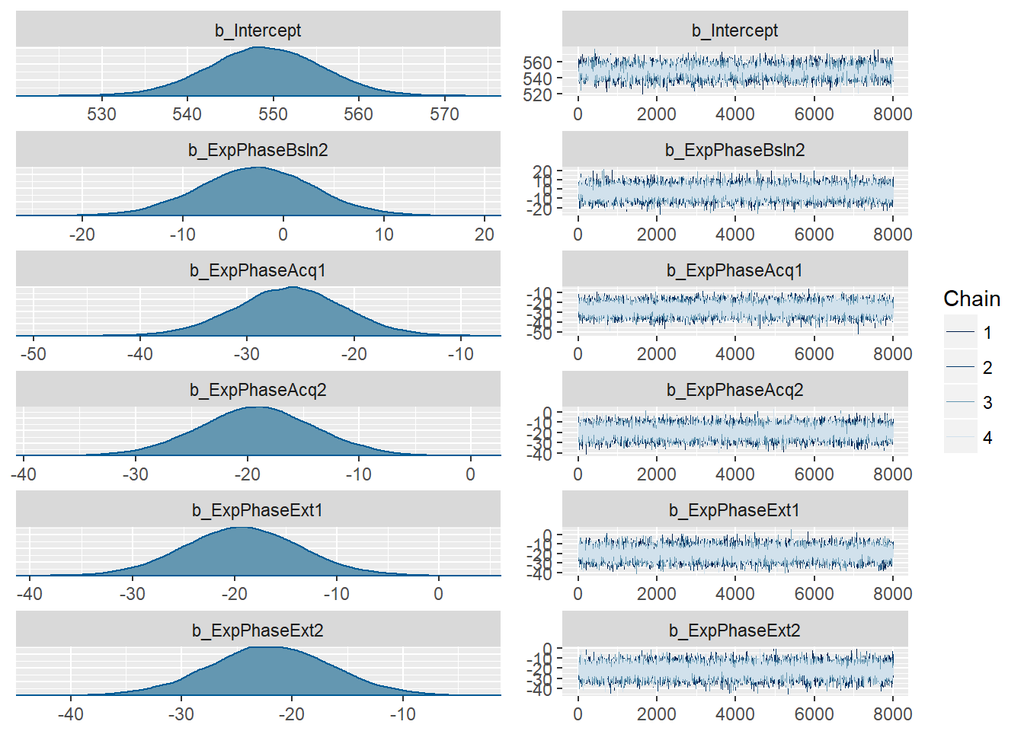

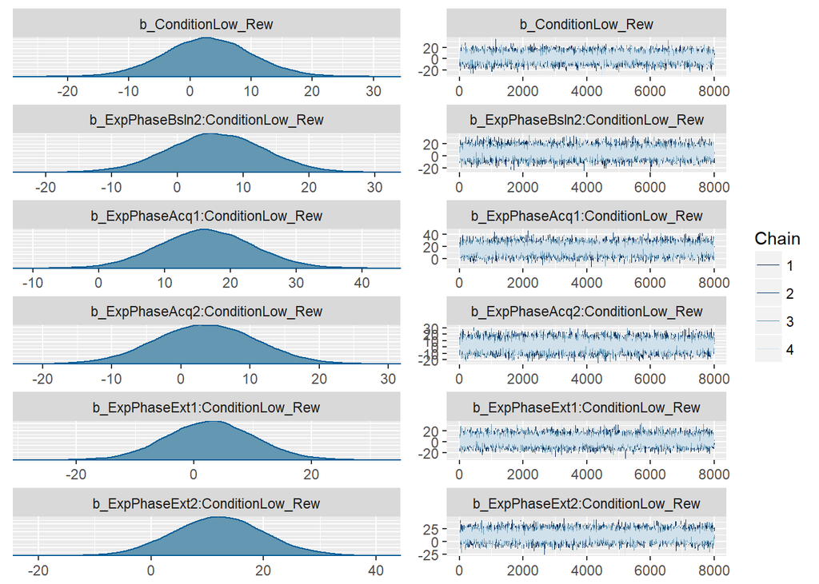

```r
# Plot chains
plot(model.full.RT, pars = "^b_", ask = FALSE, N=6)
```

Summary of the best model

```r
# Summary of the best model
print(tidy(model.full.RT, par_type = "non-varying"), digits = 1)
```

```
##                              term estimate std.error lower upper
## 1                       Intercept      549         7   538   560
## 2                   ExpPhaseBsln2       -3         6   -12     7
## 3                    ExpPhaseAcq1      -26         5   -34   -18
## 4                    ExpPhaseAcq2      -19         5   -28   -11
## 5                    ExpPhaseExt1      -19         6   -29   -10
## 6                    ExpPhaseExt2      -22         6   -31   -13
## 7                ConditionLow_Rew        3         7    -9    15
## 8  ExpPhaseBsln2:ConditionLow_Rew        6         7    -6    18
## 9   ExpPhaseAcq1:ConditionLow_Rew       16         7     5    28
## 10  ExpPhaseAcq2:ConditionLow_Rew        4         7    -8    16
## 11  ExpPhaseExt1:ConditionLow_Rew        3         7    -9    15
## 12  ExpPhaseExt2:ConditionLow_Rew       12         8    -1    26
```

### Plotting the best model

#### Sample from the posterior

```r
# Analyzing the posterior and differences between conditions

post = posterior_samples(model.full.RT, "^b")

################################################ Baseline 1 ####

######### High reward
Baseline1_High = post[["b_Intercept"]]
######### Low reward
Baseline1_Low = post[["b_Intercept"]] +
  post[["b_ConditionLow_Rew"]]

################################################ Baseline 2 ####

######### High reward
Baseline2_High = post[["b_Intercept"]] +
  post[["b_ExpPhaseBsln2"]]
######### Low reward
Baseline2_Low = post[["b_Intercept"]] +
  post[["b_ExpPhaseBsln2"]] +
  post[["b_ConditionLow_Rew"]] +
  post[["b_ExpPhaseBsln2:ConditionLow_Rew"]]

################################################ Acquistion 1

######### High reward
Acquisition1_High = post[["b_Intercept"]] +
  post[["b_ExpPhaseAcq1"]]
######### Low reward
Acquisition1_Low = post[["b_Intercept"]] +
  post[["b_ExpPhaseAcq1"]] +
  post[["b_ConditionLow_Rew"]] +
  post[["b_ExpPhaseAcq1:ConditionLow_Rew"]]

################################################ Acquistion 2

######### High reward
Acquisition2_High = post[["b_Intercept"]] +
  post[["b_ExpPhaseAcq2"]]
######### Low reward
Acquisition2_Low = post[["b_Intercept"]] +
  post[["b_ExpPhaseAcq2"]] +
  post[["b_ConditionLow_Rew"]] +
  post[["b_ExpPhaseAcq2:ConditionLow_Rew"]]

################################################ Extinction 1

######### High reward
Extinction1_High = post[["b_Intercept"]] +
  post[["b_ExpPhaseExt1"]]
######### Low reward
Extinction1_Low = post[["b_Intercept"]] +
  post[["b_ExpPhaseExt1"]] +
  post[["b_ConditionLow_Rew"]] +
  post[["b_ExpPhaseExt1:ConditionLow_Rew"]]

################################################ Extinction 2

######### High reward
Extinction2_High = post[["b_Intercept"]] +
  post[["b_ExpPhaseExt2"]]
######### Low reward
Extinction2_Low = post[["b_Intercept"]] +
  post[["b_ExpPhaseExt2"]] +
  post[["b_ConditionLow_Rew"]] +
  post[["b_ExpPhaseExt2:ConditionLow_Rew"]]
```

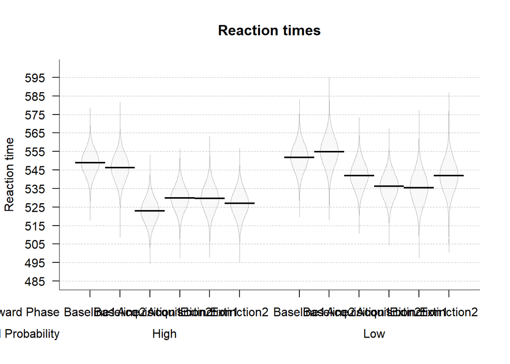

```r
# make a data frame
posterior_conditions = melt(data.frame(Baseline1_High, Baseline2_High, Baseline1_Low, Baseline2_Low, Acquisition1_High, Acquisition1_Low, Acquisition2_High, Acquisition2_Low, Extinction1_High, Extinction1_Low, Extinction2_High, Extinction2_Low))

posterior_conditions =  posterior_conditions %>% separate(variable, c("Reward Phase", "Reward Probability"), "_", extra = "merge")

names(posterior_conditions)[3] = "Reaction time"



# Pirate plot
pirateplot(formula = `Reaction time` ~ `Reward Phase` + `Reward Probability`, # dependent~independent variables
            data=posterior_conditions, # data frame
             main="Reaction times", # main title
             ylim=c(485,600), # y-axis: limits
             ylab="Reaction time", # y-axis: label
             theme=0, # preset theme (0: use your own)
             avg.line.col="black", # average line: color
             avg.line.lwd=2, # average line: line width
             avg.line.o=1, # average line: opacity (0-1)
             bean.b.col="black", # bean border, color
             bean.lwd=0.6, # bean border, line width
             bean.lty=1, # bean border, line type (1: solid; 2:dashed; 3: dotted; ...)
             bean.b.o=0.3, # bean border, opacity (0-1)
             bean.f.col="gray", # bean filling, color
             bean.f.o=.1, # bean filling, opacity (0-1)
             cap.beans=FALSE, # max and min values of bean densities are capped at the limits found in the data
             gl.col="gray", # gridlines: color
             gl.lty=2, # gridlines: line type (1: solid; 2:dashed; 3: dotted; ...)
             cex.lab=1, # axis labels: size
             cex.axis=1, # axis numbers: size
             cex.names = 1,
             sortx = "sequential",
             bty="l", # plot box type
             back.col="white") # background, color
```

Table of means across conditions

```r
# Make a table with conditions
posterior_means = as.data.frame(c("Baseline1 High Reward",
                                  "Baseline2 High Reward",
                                  "Baseline1 Low Reward",
                                  "Baseline2 Low Reward",
                                  "Acquisition1 High Reward",
                                  "Acquisition2 High Reward",
                                  "Acquisition1 Low Reward",
                                  "Acquisition2 Low Reward",
                                  "Extinction1 High Reward",
                                  "Extinction2 High Reward",
                                  "Extinction1 Low Reward",
                                  "Extinction2 Low Reward"))

names(posterior_means)[1] = "Condition"

posterior_means$Mean = c(paste(round(mean(Baseline1_High), digits = 2), " [", round(hdi(Baseline1_High)[[1]], digits = 2), " ", round(hdi(Baseline1_High)[[2]], digits = 2), "]"),
                         paste(round(mean(Baseline2_High), digits = 2), " [", round(hdi(Baseline2_High)[[1]], digits = 2), " ", round(hdi(Baseline2_High)[[2]], digits = 2), "]"),
                        paste(round(mean(Baseline1_Low), digits = 2), " [", round(hdi(Baseline1_Low)[[1]], digits = 2), " ", round(hdi(Baseline1_Low)[[2]], digits = 2), "]"),
                        paste(round(mean(Baseline2_Low), digits = 2), " [", round(hdi(Baseline2_Low)[[1]], digits = 2), " ", round(hdi(Baseline2_Low)[[2]], digits = 2), "]"),
                        paste(round(mean(Acquisition1_High), digits = 2), " [", round(hdi(Acquisition1_High)[[1]], digits = 2), " ", round(hdi(Acquisition1_High)[[2]], digits = 2), "]"),
                        paste(round(mean(Acquisition2_High), digits = 2), " [", round(hdi(Acquisition2_High)[[1]], digits = 2), " ", round(hdi(Acquisition2_High)[[2]], digits = 2), "]"),
                        paste(round(mean(Acquisition1_Low), digits = 2), " [", round(hdi(Acquisition1_Low)[[1]], digits = 2), " ", round(hdi(Acquisition1_Low)[[2]], digits = 2), "]"),
                         paste(round(mean(Acquisition2_Low), digits = 2), " [", round(hdi(Acquisition2_Low)[[1]], digits = 2), " ", round(hdi(Acquisition2_Low)[[2]], digits = 2), "]"),
                        paste(round(mean(Extinction1_High), digits = 2), " [", round(hdi(Extinction1_High)[[1]], digits = 2), " ", round(hdi(Extinction1_High)[[2]], digits = 2), "]"),
                         paste(round(mean(Extinction2_High), digits = 2), " [", round(hdi(Extinction2_High)[[1]], digits = 2), " ", round(hdi(Extinction2_High)[[2]], digits = 2), "]"),
                        paste(round(mean(Extinction1_Low), digits = 2), " [", round(hdi(Extinction1_Low)[[1]], digits = 2), " ", round(hdi(Extinction1_Low)[[2]], digits = 2), "]"),
                        paste(round(mean(Extinction2_Low), digits = 2), " [", round(hdi(Extinction2_Low)[[1]], digits = 2), " ", round(hdi(Extinction2_Low)[[2]], digits = 2), "]"))


names(posterior_means)[2] = "Mean [HDI]"

posterior_means =  posterior_means %>% separate(Condition, c("Reward Phase", "Reward Probability"), " ", extra = "merge")

kable(posterior_means, caption = "Means per condition")
```

Means per condition

| Reward Phase | Reward Probability | Mean [HDI] |
| --- | --- | --- |
| Baseline1 | High Reward | 548.95 [ 535.99 561.51 ] |
| Baseline2 | High Reward | 546.2 [ 531.5 560 ] |
| Baseline1 | Low Reward | 551.83 [ 537.82 566.18 ] |
| Baseline2 | Low Reward | 554.91 [ 539.42 571.04 ] |
| Acquisition1 | High Reward | 522.87 [ 509.89 535.59 ] |
| Acquisition2 | High Reward | 529.79 [ 516.87 542.59 ] |
| Acquisition1 | Low Reward | 542.05 [ 528.28 556.21 ] |
| Acquisition2 | Low Reward | 536.26 [ 521.92 549.75 ] |
| Extinction1 | High Reward | 529.68 [ 515.8 543.76 ] |
| Extinction2 | High Reward | 526.96 [ 512.84 540.61 ] |
| Extinction1 | Low Reward | 535.39 [ 518.62 552.17 ] |
| Extinction2 | Low Reward | 541.87 [ 525.02 557.85 ] |

### Inference about the best model

Check the difference between baseline1 vs. baseline2 in high reward

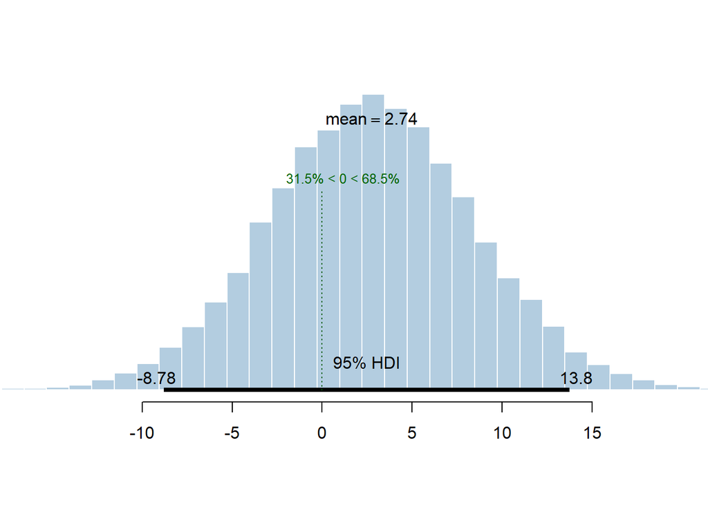

```r
Diff_Bsln1_Bsln2_High = Baseline1_High - Baseline2_High
plotPost(Diff_Bsln1_Bsln2_High, xlab = "", col = "#b3cde0", showCurve = FALSE, cex = 1, compVal = 0)
```

```r
paste("Mean = ",round(mean(Diff_Bsln1_Bsln2_High), digits = 2), " [", round(hdi(Diff_Bsln1_Bsln2_High)[[1]], digits = 2), " ", round(hdi(Diff_Bsln1_Bsln2_High)[[2]], digits = 2), "]")
```

```
## [1] "Mean =  2.74  [ -8.78   13.75 ]"
```

Check the difference between baseline1 vs. baseline2 in low reward

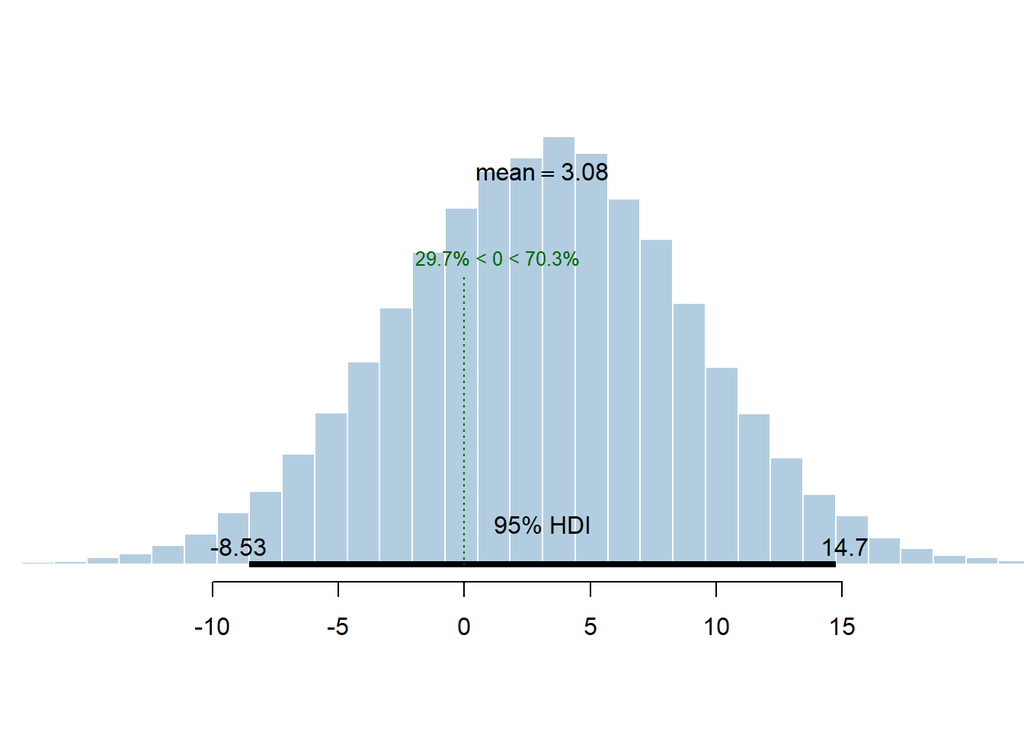

```r
Diff_Bsln1_Bsln2_Low = Baseline2_Low - Baseline1_Low
plotPost(Diff_Bsln1_Bsln2_Low, xlab = "", col = "#b3cde0", showCurve = FALSE, cex = 1, compVal = 0)
```

```r
paste("Mean = ",round(mean(Diff_Bsln1_Bsln2_Low), digits = 2), " [", round(hdi(Diff_Bsln1_Bsln2_Low)[[1]], digits = 2), " ", round(hdi(Diff_Bsln1_Bsln2_Low)[[2]], digits = 2), "]")
```

```
## [1] "Mean =  3.08  [ -8.53   14.75 ]"
```

Check the difference between baseline2 vs. acquisition1 in high reward

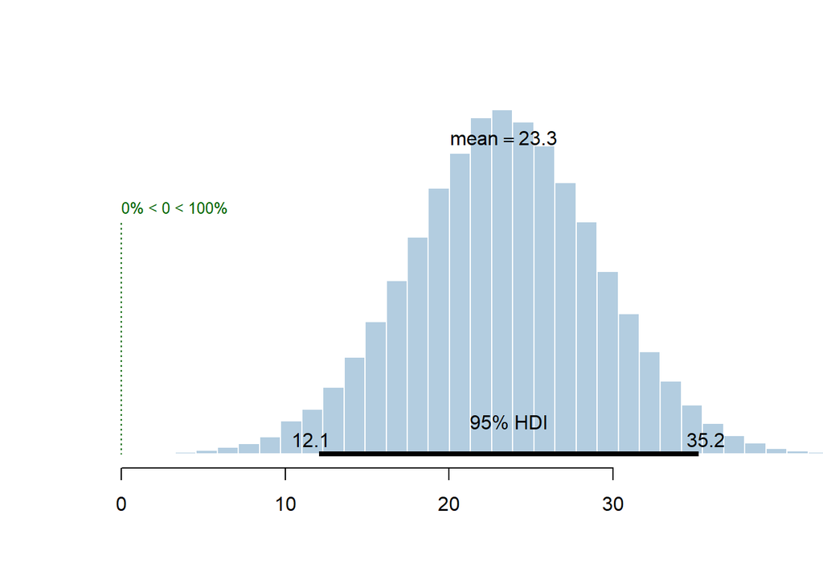

```r
Diff_Bsln2_Acq1_High = Baseline2_High - Acquisition1_High
plotPost(Diff_Bsln2_Acq1_High, xlab = "", col = "#b3cde0", showCurve = FALSE, cex = 1, compVal = 0)
```

```r
paste("Mean = ",round(mean(Diff_Bsln2_Acq1_High), digits = 2), " [", round(hdi(Diff_Bsln2_Acq1_High)[[1]], digits = 2), " ", round(hdi(Diff_Bsln2_Acq1_High)[[2]], digits = 2), "]")
```

```
## [1] "Mean =  23.34  [ 12.06   35.22 ]"
```

Check the difference between baseline2 vs. acquisition1 in low reward

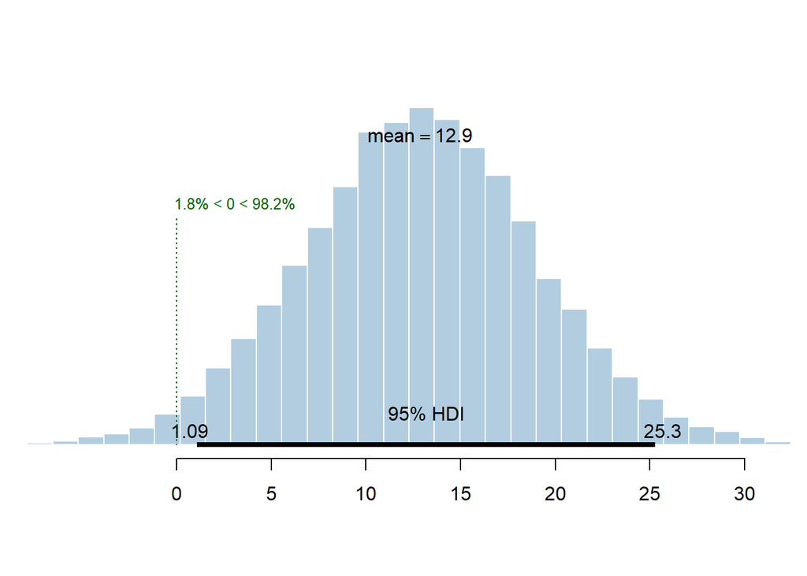

```r
Diff_Bsln2_Acq1_Low = Baseline2_Low - Acquisition1_Low
plotPost(Diff_Bsln2_Acq1_Low, xlab = "", col = "#b3cde0", showCurve = FALSE, cex = 1, compVal = 0)
```

```r
paste("Mean = ",round(mean(Diff_Bsln2_Acq1_Low), digits = 2), " [", round(hdi(Diff_Bsln2_Acq1_Low)[[1]], digits = 2), " ", round(hdi(Diff_Bsln2_Acq1_Low)[[2]], digits = 2), "]")
```

```
## [1] "Mean =  12.86  [ 1.09   25.28 ]"
```